# Coursera Practical Machine Learning Project

Masamichi Kawarabayashi

Dec 30, 2018

This is a report of final project of **Practical Machine Learning** course in Coursera.

## Introduction

The goal will be to use data from accelerometers on the belt, forearm, arm, and dumbell of 6 participants. They were asked to perform barbell lifts correctly and incorrectly in 5 different ways. More information is available from the website here: http://web.archive.org/web/20161224072740/http:/groupware.les.inf.puc-rio.br/har (see the section on the Weight Lifting Exercise Dataset).

```r
library(caret)
library(dplyr)
library(randomForest)
```

```r
library(ggplot2)
library(rattle)
```

## Read and clean up data

Read data from the provided URL, replacing blanks and unexpected values to NA. Then create data set which columns has 5% less NA percentage. Also first 7 columns are removed because they are not used in this analysis.

```r
training.org <- read.csv(url("https://d396qusza40orc.cloudfront.net/predmachlearn/pml-training.csv"), header=TRUE, na.strings=c("NA","#DIV/0!",""))
testing.org  <- read.csv(url("https://d396qusza40orc.cloudfront.net/predmachlearn/pml-testing.csv"), header=TRUE, na.strings=c("NA","#DIV/0!",""))
str(training.org$class)
```

```
##  Factor w/ 5 levels "A","B","C","D",..: 1 1 1 1 1 1 1 1 1 1 ...
```

```r
dim(training.org); dim(testing.org)
```

```
## [1] 19622   160
```

```
## [1]  20 160
```

```r
training.org.clean <- select(training.org, which(as.logical(sapply(training.org, function(y) sum(is.na(y)))/dim(training.org)[1]<0.05)))
testing.org.clean  <- select(testing.org, which(as.logical(sapply(testing.org, function(y) sum(is.na(y)))/dim(testing.org)[1]<0.05)))
training.org.clean <- training.org.clean[, -c(1:7)]
testing.org.clean <- testing.org.clean[, -c(1:7)]
dim(training.org.clean); dim(testing.org.clean)
```

```
## [1] 19622    53
```

```
## [1] 20 53
```

```r
inTrain <- createDataPartition(training.org.clean$classe, p=0.8, list=FALSE)
training <- training.org.clean[inTrain,]
testing <- training.org.clean[-inTrain,]
```

Now the cleaned training/test data have 53 columns. And training and test set are prepared.

## Analysis with classification tree

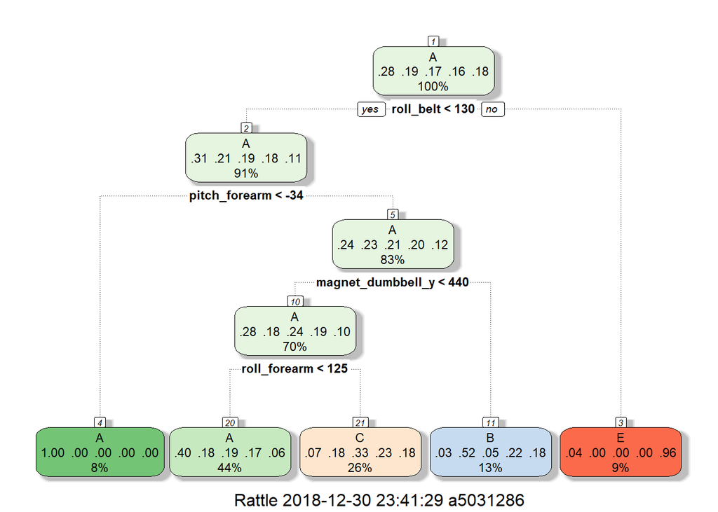

```r
set.seed(1960)
model.ct <- train(classe~., data=training, method="rpart", trControl=trainControl(method="cv", number=5))
fancyRpartPlot(model.ct$finalModel)
```

```r
pred.ct <- predict(model.ct, testing)
confmt <- confusionMatrix(testing$classe, pred.ct)
confmt$table
```

```
##           Reference
## Prediction   A   B   C   D   E
##          A 989  13  95   0  19
##          B 317 257 185   0   0
##          C 308  18 358   0   0
##          D 293 126 224   0   0
##          E  99 104 191   0 327
```

```r
confmt$overall["Accuracy"]
```

```
##  Accuracy
## 0.4922253
```

The accuracy is only 49%, so this model can not predict the outcome **classe** well.

## Analysis with gradient boosting method

```r
set.seed(1960)
model.gbm <- train(classe~., data=training, method="gbm", trControl=trainControl(method="cv", number=5), verbose=FALSE)
model.gbm
```

```
## Stochastic Gradient Boosting
##
## 15699 samples
##    52 predictor
##     5 classes: 'A', 'B', 'C', 'D', 'E'
##
## No pre-processing
## Resampling: Cross-Validated (5 fold)
## Summary of sample sizes: 12560, 12558, 12557, 12561, 12560
## Resampling results across tuning parameters:
##
##   interaction.depth  n.trees  Accuracy   Kappa
##   1                   50      0.7507463  0.6840178
##   1                  100      0.8219642  0.7746678
##   1                  150      0.8528558  0.8138367
##   2                   50      0.8534925  0.8143617
##   2                  100      0.9059798  0.8810026
##   2                  150      0.9317134  0.9135767
##   3                   50      0.8959795  0.8683358
##   3                  100      0.9443897  0.9296276
##   3                  150      0.9624172  0.9524479
##
## Tuning parameter 'shrinkage' was held constant at a value of 0.1
##
## Tuning parameter 'n.minobsinnode' was held constant at a value of 10
## Accuracy was used to select the optimal model using the largest value.
## The final values used for the model were n.trees = 150,
##  interaction.depth = 3, shrinkage = 0.1 and n.minobsinnode = 10.
```

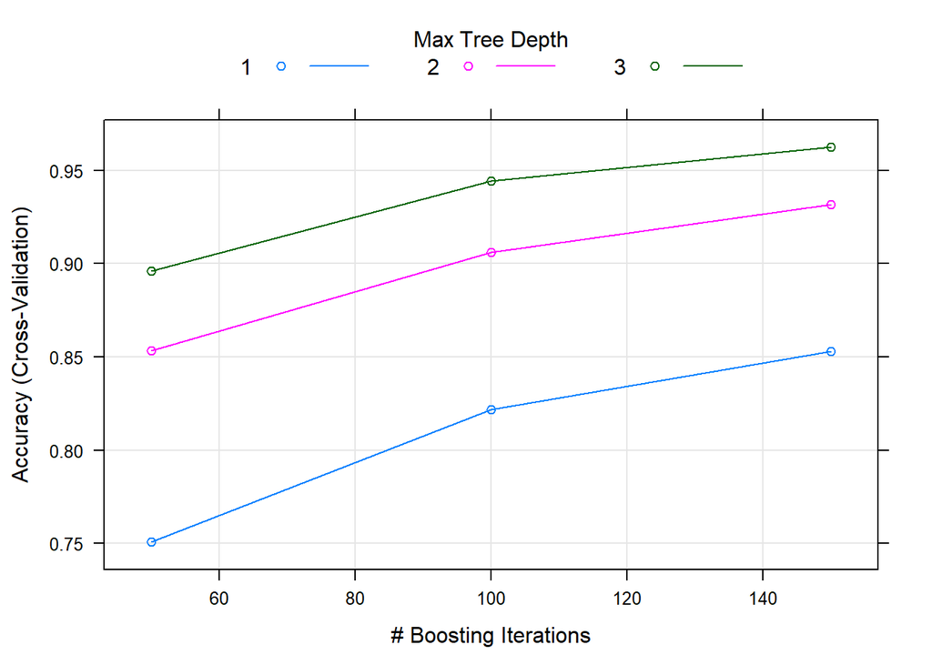

```r
plot(model.gbm)
```

```r
pred.gbm <- predict(model.gbm, testing)
confmt <- confusionMatrix(testing$classe, pred.gbm)
confmt$table
```

```
##           Reference
## Prediction    A    B    C    D    E
##          A 1095   14    5    2    0
##          B   19  715   23    2    0
##          C    0   19  657    7    1
##          D    0    5   29  605    4
##          E    4   10    7   11  689
```

```r
confmt$overall["Accuracy"]
```

```
##  Accuracy
## 0.9587051
```

The accuracy is 96%, so this model can predict the outcome **classe** well.

## Analysis with random forest

```r
set.seed(1960)
model.rf <- randomForest(classe~.,data=training,ntree=200,importance=TRUE)
model.rf
```

```
##
## Call:
##  randomForest(formula = classe ~ ., data = training, ntree = 200,      importance = TRUE)
##                Type of random forest: classification
##                      Number of trees: 200
## No. of variables tried at each split: 7
##
##         OOB estimate of  error rate: 0.47%
## Confusion matrix:
##      A    B    C    D    E class.error
## A 4461    2    0    0    1 0.000672043
## B   13 3021    4    0    0 0.005595787
## C    0   15 2719    4    0 0.006939372
## D    0    0   28 2543    2 0.011659541
## E    0    0    2    3 2881 0.001732502
```

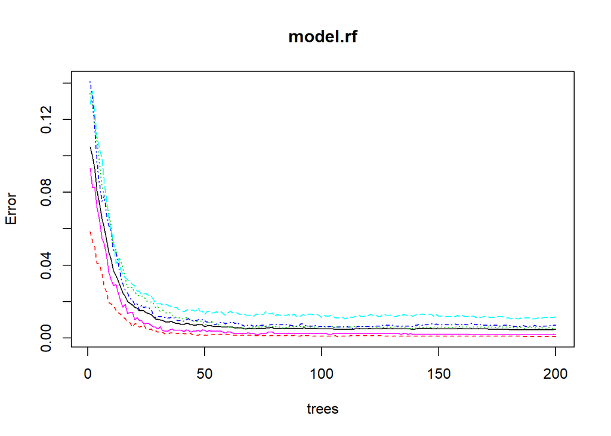

```r
plot(model.rf)
```

```r
pred.rf <- predict(model.rf, testing)
confmt <- confusionMatrix(testing$classe, pred.rf)
confmt$table
```

```
##           Reference
## Prediction    A    B    C    D    E
##          A 1116    0    0    0    0
##          B    1  756    2    0    0
##          C    0    1  683    0    0
##          D    0    0    2  639    2
##          E    0    0    0    5  716
```

```r
confmt$overall["Accuracy"]
```

```
##  Accuracy
## 0.9966862
```

The accuracy is 99.6%, so this model can predict the outcome **classe** well.

### Important variables

The importance of the variables are shown below.

```r
varImp(model.rf)
```

```
##                              A        B         C         D         E
## roll_belt            23.646850 26.06038 27.904326 27.757281 26.730684
## pitch_belt           19.568734 32.17015 26.001407 21.953129 21.903986
## yaw_belt             29.535222 29.55428 31.207846 31.596539 24.127844
## total_accel_belt      8.093842 10.18173  8.472693  8.618195  9.156145
## gyros_belt_x         11.947743 11.61141 12.281680  8.963509  9.711916
## gyros_belt_y          6.809356 11.14313 11.252702  8.652334 10.635152
## gyros_belt_z         13.419486 17.75496 17.039032 13.477530 17.054721
## accel_belt_x          9.967855 12.01545 11.566798  8.906671  9.539169
## accel_belt_y          9.986120 12.72311  9.298537 10.215625  8.230196
## accel_belt_z         15.542653 17.97151 17.506655 14.341672 12.696413
## magnet_belt_x        12.168719 18.21943 16.021707 15.220771 14.894789
## magnet_belt_y        14.371426 17.44835 17.319835 17.310882 16.238022
## magnet_belt_z        14.084587 15.86296 14.709075 17.594504 14.062241
## roll_arm             13.979049 21.27786 18.327590 17.561760 14.359072
## pitch_arm            14.082142 15.87867 15.861693 13.327157 11.485843
## yaw_arm              14.330518 17.64171 15.728978 16.683617 11.705515
## total_accel_arm       7.559544 15.24054 13.948417 13.102138 12.794688
## gyros_arm_x          12.183780 16.56456 16.962912 16.883764 14.096681
## gyros_arm_y          14.081644 21.12851 15.914677 17.860645 13.142503
## gyros_arm_z           8.953416 10.09192 10.934105  9.832125  7.161455
## accel_arm_x          10.638184 12.14769 12.035009 13.481810  9.774446
## accel_arm_y          11.623622 14.00730 10.878198 11.440424 12.075734
## accel_arm_z           7.793306 11.56236 13.426963 13.305773 12.531113
## magnet_arm_x         11.237484 10.43510 11.779654 11.929499 10.233181
## magnet_arm_y          7.639705 10.65991 11.481156 13.751240  9.674266
## magnet_arm_z         15.400356 18.64638 16.557933 15.271325 13.661427
## roll_dumbbell        16.111444 17.82545 18.533913 18.378051 17.092101
## pitch_dumbbell        8.424021 12.79061 11.366916  8.340915  9.352962
## yaw_dumbbell         11.144873 13.76591 13.831007 12.909346 14.807507
## total_accel_dumbbell 12.044093 14.64275 13.205121 14.018378 16.359459
## gyros_dumbbell_x     11.634500 18.16268 14.084777 14.956471 13.476616
## gyros_dumbbell_y     13.275800 15.02854 17.241546 14.903674 13.461721
## gyros_dumbbell_z     12.017996 17.34367 13.535593 11.146685 10.993782
## accel_dumbbell_x     10.631245 14.19931 12.632657 11.880459 12.552219
## accel_dumbbell_y     16.487717 17.60288 20.297019 18.083093 18.512914
## accel_dumbbell_z     14.046763 16.20681 16.238067 16.197503 19.053651
## magnet_dumbbell_x    15.166885 17.03835 19.383258 16.782638 13.829157
## magnet_dumbbell_y    24.493642 23.24523 27.860629 23.161252 20.176702
## magnet_dumbbell_z    26.829429 26.19571 31.023640 23.834283 22.855098
## roll_forearm         18.179846 16.69997 19.742737 15.039391 15.725379
## pitch_forearm        19.554739 22.67000 25.065905 21.457274 21.912198
## yaw_forearm          12.814449 13.92601 13.880489 12.186595 13.131799
## total_accel_forearm  11.723735 13.62380 14.263923 10.729528 11.104177
## gyros_forearm_x       9.024761 12.31116 11.468527 12.424978  9.228086
## gyros_forearm_y      12.616397 18.64946 17.149274 15.616780 13.531652
## gyros_forearm_z      10.886130 16.35829 15.815199 11.738507 13.136722
## accel_forearm_x      11.469211 15.69424 15.209703 17.042583 13.814170
## accel_forearm_y      12.208144 15.01002 14.750909 11.684624 14.625100
## accel_forearm_z      11.294911 13.90804 16.741209 14.399026 15.081610
## magnet_forearm_x     10.304391 16.40070 13.710748 13.244713 16.838743
## magnet_forearm_y     12.598711 13.53023 15.472127 13.292635 12.807140
## magnet_forearm_z     15.283628 18.75752 18.310507 17.188564 15.807670
```

# Conclusion

Based on the above trials, **random forest** model is the best one to predict it. So predict **classe** with original test (validation) data.

```r
pred.testing <- predict(model.rf, testing.org.clean)
pred.testing
```

```
##  1  2  3  4  5  6  7  8  9 10 11 12 13 14 15 16 17 18 19 20
##  B  A  B  A  A  E  D  B  A  A  B  C  B  A  E  E  A  B  B  B
## Levels: A B C D E
```